# Soil Carbon Analysis

Marc Los Huertos

EA030 · Compiled 2026-05-26

EA030 — RTricks — Activity 17

# Soil Carbon Analysis: Depth Profiles and Land-Use Comparisons

**Prof. Marc Los Huertos** • Pomona College • Environmental Analysis

← Back to RTricks

Introduction Setup & Data Import & Clean Depth Profiles Fitting Models Land-Use Comparison Carbon Stocks Inferential Tests Summary

#### 🎯 Learning Outcomes

1. Import and clean a multi-site, multi-horizon soil survey dataset using `readr` and `dplyr`.
2. Visualise organic carbon concentration as a function of depth using flipped coordinate plots.
3. Fit and compare exponential decay and polynomial depth-profile models with `nls()` and `lm()`.
4. Calculate soil organic carbon stocks (Mg C ha⁻¹) by integrating concentration over depth using bulk density.
5. Compare SOC stocks across land-use treatments using one-way ANOVA with post-hoc Tukey tests.
6. Communicate model uncertainty with confidence and prediction intervals on profile plots.

> **What this activity covers.** Soil organic carbon (SOC) is the largest terrestrial carbon pool — roughly twice the carbon held in the atmosphere. How much SOC a soil holds, and how it is distributed with depth, depends strongly on land use: native vegetation typically stores far more carbon than cultivated or degraded soils. In this activity you will import and clean a simulated soil survey dataset, fit depth-profile models, calculate carbon stocks to 1 m depth, and test whether land-use treatments differ significantly — a workflow directly applicable to the EA030 compost and land-use projects.

## The Analytical Pipeline

Stage 1

Import & Clean

Read CSV, fix horizon mid-depths, flag QA issues, filter to analysis-ready records.

Stage 2

Depth Profiles

Plot SOC vs depth for each site and land use. Flip coordinates so depth increases downward.

Stage 3

Fit Models

Exponential decay with nls(); polynomial with lm(). Compare AIC. Add CI ribbons to profile plots.

Stage 4

Carbon Stocks

Integrate SOC × bulk density × horizon thickness to get Mg C ha⁻¹ to a fixed reference depth.

Stage 5

Compare Treatments

ANOVA and Tukey HSD test whether land-use treatments differ in total SOC stock.

## 1. Setup

### 1.1 Packages

```r
library(tidyverse)   # dplyr, tidyr, ggplot2, readr
library(broom)       # tidy() model summaries
library(knitr)       # kable() tables
library(kableExtra)  # styled tables
```

### 1.2 Simulated soil survey data

The dataset is modelled on soil surveys from paired land-use plots in Southern California: **native chaparral**, **annual grassland** (invaded by non-native species), **cultivated cropland**, and **restored native** (10-year revegetation). Each land use has 5 replicate sites, each sampled at standard horizon mid-depths (5, 15, 30, 50, 75, and 100 cm).

```r
set.seed(2024)

land_uses <- c("native_chaparral", "annual_grassland",
               "cultivated",       "restored_native")
n_sites   <- 5    # replicates per land use
depths_cm <- c(5, 15, 30, 50, 75, 100)

# Exponential decay parameters (A = surface SOC g/kg, k = decay rate /cm)
# Bulk density (g/cm³) increases with depth for all land uses
params <- tribble(
  ~land_use,          ~A,    ~k,      ~bd_surface, ~bd_deep,
  "native_chaparral",  62,   0.028,   0.82,        1.25,
  "annual_grassland",  34,   0.032,   0.95,        1.32,
  "cultivated",        22,   0.038,   1.10,        1.45,
  "restored_native",   48,   0.030,   0.88,        1.28
)

soil_raw <- params %>%
  rowwise() %>%
  reframe(
    land_use    = land_use,
    site_id     = paste0(substr(land_use, 1, 3), "_", str_pad(1:n_sites, 2, "left", "0")),
    depth_cm    = list(depths_cm)
  ) %>%
  unnest(depth_cm) %>%
  left_join(params, by = "land_use") %>%
  mutate(
    # SOC concentration: exponential decay + site-level random effect + noise
    site_effect = rnorm(n(), 0, 4),
    soc_g_kg    = pmax(0.5,
                    A * exp(-k * depth_cm) +
                    site_effect * exp(-0.02 * depth_cm) +
                    rnorm(n(), 0, 1.5)),
    # Bulk density: linear increase from surface to 100 cm
    bulk_density_g_cm3 = bd_surface +
                         (bd_deep - bd_surface) * depth_cm / 100 +
                         rnorm(n(), 0, 0.03),
    bulk_density_g_cm3 = pmax(0.6, bulk_density_g_cm3),
    # Horizon thickness (cm) for stock calculation
    horizon_thick_cm   = case_when(
      depth_cm ==   5 ~ 10,
      depth_cm ==  15 ~ 10,
      depth_cm ==  30 ~ 20,
      depth_cm ==  50 ~ 20,
      depth_cm ==  75 ~ 25,
      depth_cm == 100 ~ 25
    )
  ) %>%
  select(land_use, site_id, depth_cm, horizon_thick_cm,
         soc_g_kg, bulk_density_g_cm3)

glimpse(soil_raw)
```

```
## Rows: 120
## Columns: 6
## $ land_use           <chr> "native_chaparral", "native_chaparral", "native_cha…
## $ site_id            <chr> "nat_01", "nat_01", "nat_01", "nat_01", "nat_01", "…
## $ depth_cm           <dbl> 5, 15, 30, 50, 75, 100, 5, 15, 30, 50, 75, 100, 5, …
## $ horizon_thick_cm   <dbl> 10, 10, 20, 20, 25, 25, 10, 10, 20, 20, 25, 25, 10,…
## $ soc_g_kg           <dbl> 57.056398, 41.632982, 24.573514, 14.679824, 7.55876…
## $ bulk_density_g_cm3 <dbl> 0.8480238, 0.9172507, 0.9899496, 1.0690255, 1.11519…
```

**📄 Using your own data.** If you are bringing real soil survey data from the EA030 field campaign, swap in your CSV at the import step below. Your file needs at minimum: a **site identifier**, a **depth column** (cm), an **SOC column** (g/kg or %), and a **bulk density column** (g/cm³). If bulk density was not measured, use a published pedotransfer function — the Saxton-Rawls equations are a common choice for California soils.

## 2. Import and Clean

### 2.1 Write and re-read as a CSV (simulating a real import)

In a real project you would load your data with `read_csv()`. Here we write the simulated data to disk and read it back so the workflow is identical.

```r
# Write to a temporary file — replace this path with your real data file
tmp <- tempfile(fileext = ".csv")
write_csv(soil_raw, tmp)

# Import exactly as you would in a real project
soil <- read_csv(tmp, show_col_types = FALSE)
glimpse(soil)
```

```
## Rows: 120
## Columns: 6
## $ land_use           <chr> "native_chaparral", "native_chaparral", "native_cha…
## $ site_id            <chr> "nat_01", "nat_01", "nat_01", "nat_01", "nat_01", "…
## $ depth_cm           <dbl> 5, 15, 30, 50, 75, 100, 5, 15, 30, 50, 75, 100, 5, …
## $ horizon_thick_cm   <dbl> 10, 10, 20, 20, 25, 25, 10, 10, 20, 20, 25, 25, 10,…
## $ soc_g_kg           <dbl> 57.056398, 41.632982, 24.573514, 14.679824, 7.55876…
## $ bulk_density_g_cm3 <dbl> 0.8480238, 0.9172507, 0.9899496, 1.0690255, 1.11519…
```

### 2.2 Quality checks

Before any analysis, verify that the data look physically reasonable.

```r
cat("=== Basic dimensions ===\n")
```

```
## === Basic dimensions ===
```

```r
cat("Rows:", nrow(soil), "| Sites:", n_distinct(soil$site_id),
    "| Land uses:", n_distinct(soil$land_use), "\n\n")
```

```
## Rows: 120 | Sites: 20 | Land uses: 4
```

```r
cat("=== Missing values per column ===\n")
```

```
## === Missing values per column ===
```

```r
soil %>% summarise(across(everything(), ~ sum(is.na(.)))) %>% print()
```

```
## # A tibble: 1 × 6
##   land_use site_id depth_cm horizon_thick_cm soc_g_kg bulk_density_g_cm3
##      <int>   <int>    <int>            <int>    <int>              <int>
## 1        0       0        0                0        0                  0
```

```r
cat("\n=== SOC range (g/kg) ===\n")
```

```
##
## === SOC range (g/kg) ===
```

```r
summary(soil$soc_g_kg)
```

```
##    Min. 1st Qu.  Median    Mean 3rd Qu.    Max.
##   0.500   4.612  10.982  15.605  23.845  57.056
```

```r
cat("\n=== Bulk density range (g/cm³) ===\n")
```

```
##
## === Bulk density range (g/cm³) ===
```

```r
summary(soil$bulk_density_g_cm3)
```

```
##    Min. 1st Qu.  Median    Mean 3rd Qu.    Max.
##  0.7653  0.9940  1.1243  1.1172  1.2448  1.4635
```

```r
# Flag physically implausible values
soil <- soil %>%
  mutate(
    flag_soc = soc_g_kg < 0 | soc_g_kg > 200,
    flag_bd  = bulk_density_g_cm3 < 0.4 | bulk_density_g_cm3 > 2.0
  )

cat("\n=== Flagged rows ===\n")
```

```
##
## === Flagged rows ===
```

```r
soil %>% filter(flag_soc | flag_bd) %>% print()
```

```
## # A tibble: 0 × 8
## # ℹ 8 variables: land_use <chr>, site_id <chr>, depth_cm <dbl>,
## #   horizon_thick_cm <dbl>, soc_g_kg <dbl>, bulk_density_g_cm3 <dbl>,
## #   flag_soc <lgl>, flag_bd <lgl>
```

**⚠️ Common real-data problems to watch for.** SOC values above 200 g/kg suggest an organic horizon (O horizon) that may need separate treatment. Bulk density below 0.4 g/cm³ is physically unrealistic for mineral soil. Negative values in either column indicate data-entry errors. Check them before proceeding.

### 2.3 Standardise land-use labels and factor ordering

```r
soil <- soil %>%
  filter(!flag_soc, !flag_bd) %>%         # remove any flagged rows
  select(-flag_soc, -flag_bd) %>%
  mutate(
    land_use = factor(land_use,
      levels = c("native_chaparral", "restored_native",
                 "annual_grassland",  "cultivated"),
      labels = c("Native chaparral", "Restored native",
                 "Annual grassland",  "Cultivated")
    )
  )

# Confirm sample size per land use × depth combination
soil %>%
  count(land_use, depth_cm) %>%
  pivot_wider(names_from = depth_cm, values_from = n) %>%
  kbl(caption = "Sample counts per land use and depth (cm)") %>%
  kable_styling(bootstrap_options = c("striped","hover"), full_width = FALSE)
```

Sample counts per land use and depth (cm)

| land_use | 5 | 15 | 30 | 50 | 75 | 100 |
| --- | --- | --- | --- | --- | --- | --- |
| Native chaparral | 5 | 5 | 5 | 5 | 5 | 5 |
| Restored native | 5 | 5 | 5 | 5 | 5 | 5 |
| Annual grassland | 5 | 5 | 5 | 5 | 5 | 5 |
| Cultivated | 5 | 5 | 5 | 5 | 5 | 5 |

## 3. Depth Profile Visualisation

### 3.1 Profile plot with depth on the vertical axis

In soil science, depth always increases **downward**. We achieve this in ggplot2 with `scale_y_reverse()` on a flipped-coordinate plot.

[figure not shown]

```r
lu_colors <- c(
  "Native chaparral" = "#1e3a2f",
  "Restored native"  = "#4a7c5e",
  "Annual grassland" = "#c8832a",
  "Cultivated"       = "#8b4513"
)

ggplot(soil, aes(x = soc_g_kg, y = depth_cm,
                 color = land_use, group = interaction(land_use, site_id))) +
  geom_line(alpha = 0.35, linewidth = 0.6) +
  geom_point(alpha = 0.55, size = 1.8) +
  # Add land-use mean profile
  stat_summary(
    aes(group = land_use),
    fun   = mean,
    geom  = "line",
    linewidth = 1.4,
    alpha = 0.95
  ) +
  scale_y_reverse(breaks = depths_cm) +
  scale_color_manual(values = lu_colors, name = NULL) +
  labs(
    title    = "Soil organic carbon depth profiles by land use",
    subtitle = "Thin lines = individual sites; thick lines = land-use means",
    x        = "SOC concentration (g kg\u207b\u00b9)",
    y        = "Depth (cm)"
  ) +
  theme_minimal(base_size = 12) +
  theme(
    plot.title     = element_text(family = "serif", face = "bold",
                                  color = "#1e3a2f", size = 13),
    plot.subtitle  = element_text(color = "#7a7a72", size = 10),
    legend.position = "bottom",
    panel.grid.minor = element_blank()
  )
```

**📌 Reading a depth profile.** SOC is always highest at the surface where plant litter inputs are greatest and declines with depth as microbial decomposition and root inputs diminish. The **steepness** of the decline captures how deeply carbon is stored — native vegetation with deep roots typically maintains higher SOC at depth than disturbed or cultivated soils.

### 3.2 Faceted profiles — one panel per land use

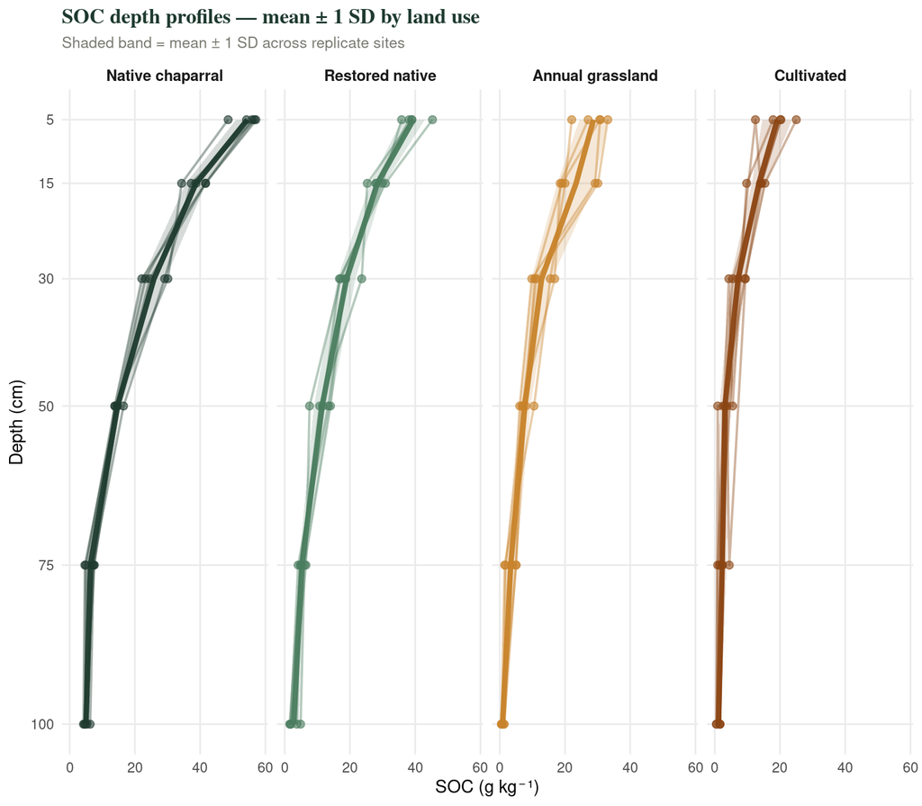

```r
# Pre-compute mean ± 1 SD per land use × depth for the ribbon
soil_ribbon <- soil %>%
  group_by(land_use, depth_cm) %>%
  summarise(
    soc_mean = mean(soc_g_kg),
    soc_lo   = mean(soc_g_kg) - sd(soc_g_kg),
    soc_hi   = mean(soc_g_kg) + sd(soc_g_kg),
    .groups  = "drop"
  )

ggplot(soil, aes(x = soc_g_kg, y = depth_cm, color = land_use)) +
  geom_line(aes(group = site_id), alpha = 0.4, linewidth = 0.7) +
  geom_point(size = 2, alpha = 0.6) +
  # Mean ± 1 SD ribbon from pre-computed data
  geom_ribbon(data = soil_ribbon,
              aes(x = soc_mean, y = depth_cm,
                  xmin = soc_lo, xmax = soc_hi,
                  fill = land_use),
              alpha = 0.18, color = NA) +
  # Mean profile line from pre-computed data
  geom_line(data = soil_ribbon,
            aes(x = soc_mean, y = depth_cm, color = land_use),
            linewidth = 1.6, alpha = 0.95) +
  scale_y_reverse(breaks = depths_cm) +
  scale_color_manual(values = lu_colors, name = NULL) +
  scale_fill_manual(values  = lu_colors, guide = "none") +
  facet_wrap(~ land_use, nrow = 1) +
  labs(
    title    = "SOC depth profiles — mean ± 1 SD by land use",
    subtitle = "Shaded band = mean ± 1 SD across replicate sites",
    x        = "SOC (g kg\u207b\u00b9)",
    y        = "Depth (cm)"
  ) +
  theme_minimal(base_size = 11) +
  theme(
    plot.title      = element_text(family = "serif", face = "bold",
                                   color = "#1e3a2f", size = 13),
    plot.subtitle   = element_text(color = "#7a7a72", size = 9.5),
    legend.position = "none",
    strip.text      = element_text(face = "bold", size = 9.5),
    panel.grid.minor = element_blank()
  )
```

## 4. Fitting Depth-Profile Models

Two model families are commonly used for SOC depth profiles:

| Model | Formula | When to use |
| --- | --- | --- |
| **Exponential decay** | SOC = A · e^(−k · depth) | Physically interpretable; A = surface SOC, k = decay rate |
| **Polynomial (log-linear)** | log(SOC) = β₀ + β₁·depth | Flexible; easy to fit with `lm()`; less interpretable |

### 4.1 Exponential decay with `nls()`

`nls()` (non-linear least squares) fits models where parameters enter non-linearly. We must supply starting values — use the known true values as starting guesses.

```r
# Fit one exponential model per land use
exp_fits <- soil %>%
  group_by(land_use) %>%
  group_modify(~ {
    tryCatch(
      broom::tidy(
        nls(soc_g_kg ~ A * exp(-k * depth_cm),
            data  = .x,
            start = list(A = 50, k = 0.03),
            control = nls.control(maxiter = 200))
      ) %>% mutate(.rows = nrow(.x)),
      error = function(e) tibble(term = "error", estimate = NA_real_,
                                 std.error = NA_real_, statistic = NA_real_,
                                 p.value = NA_real_, .rows = nrow(.x))
    )
  }) %>%
  ungroup()

exp_fits %>%
  select(land_use, term, estimate, std.error, p.value) %>%
  mutate(across(where(is.numeric), ~ round(.x, 4))) %>%
  kbl(caption = "Exponential decay parameters by land use  (SOC = A · exp(−k · depth))") %>%
  kable_styling(bootstrap_options = c("striped","hover"), full_width = FALSE)
```

Exponential decay parameters by land use (SOC = A · exp(−k · depth))

| land_use | term | estimate | std.error | p.value |
| --- | --- | --- | --- | --- |
| Native chaparral | A | 62.1523 | 1.3858 | 0 |
| Native chaparral | k | 0.0294 | 0.0012 | 0 |
| Restored native | A | 44.8325 | 1.2097 | 0 |
| Restored native | k | 0.0284 | 0.0014 | 0 |
| Annual grassland | A | 34.4527 | 1.8000 | 0 |
| Annual grassland | k | 0.0307 | 0.0029 | 0 |
| Cultivated | A | 23.1039 | 1.4244 | 0 |
| Cultivated | k | 0.0372 | 0.0040 | 0 |

**⚙️ Interpreting A and k.** **A** (g/kg) is the modelled SOC at depth = 0 (the soil surface). **k** (/cm) is the exponential decay rate — larger k means carbon declines more steeply with depth. Native chaparral should have the highest A and one of the lower k values (deep carbon storage), while cultivated soil should have low A and high k (carbon concentrated near the ploughed surface).

### 4.2 Log-linear model with `lm()`

```r
lm_fits <- soil %>%
  group_by(land_use) %>%
  group_modify(~ broom::glance(
    lm(log(soc_g_kg) ~ depth_cm, data = .x)
  )) %>%
  ungroup()

lm_fits %>%
  select(land_use, r.squared, AIC, BIC) %>%
  mutate(across(where(is.numeric), ~ round(.x, 3))) %>%
  kbl(caption = "Log-linear model fit statistics by land use") %>%
  kable_styling(bootstrap_options = c("striped","hover"), full_width = FALSE)
```

Log-linear model fit statistics by land use

| land_use | r.squared | AIC | BIC |
| --- | --- | --- | --- |
| Native chaparral | 0.959 | -11.188 | -6.984 |
| Restored native | 0.947 | 2.535 | 6.739 |
| Annual grassland | 0.926 | 27.574 | 31.777 |
| Cultivated | 0.823 | 46.968 | 51.172 |

### 4.3 Profile plot with model fits and confidence intervals

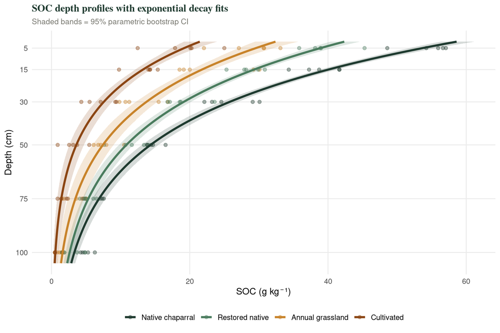

```r
# Generate predicted values over a fine depth grid for each land use
depth_grid <- tibble(depth_cm = seq(2, 105, by = 1))

pred_curves <- soil %>%
  group_by(land_use) %>%
  group_modify(~ {
    fit <- tryCatch(
      nls(soc_g_kg ~ A * exp(-k * depth_cm),
          data  = .x,
          start = list(A = 50, k = 0.03),
          control = nls.control(maxiter = 200)),
      error = function(e) NULL
    )
    if (is.null(fit)) return(tibble())
    # Confidence interval via parametric bootstrap
    set.seed(42)
    pred_boot <- replicate(500, {
      coefs <- MASS::mvrnorm(1,
                             mu    = coef(fit),
                             Sigma = vcov(fit))
      coefs["A"] * exp(-coefs["k"] * depth_grid$depth_cm)
    })
    tibble(
      depth_cm  = depth_grid$depth_cm,
      fitted    = predict(fit, newdata = depth_grid),
      ci_lo     = apply(pred_boot, 1, quantile, 0.025),
      ci_hi     = apply(pred_boot, 1, quantile, 0.975)
    )
  }) %>%
  ungroup()

ggplot() +
  # Raw data points
  geom_point(data = soil,
             aes(x = soc_g_kg, y = depth_cm, color = land_use),
             alpha = 0.4, size = 1.8) +
  # CI ribbon
  geom_ribbon(data = pred_curves,
              aes(x = fitted, y = depth_cm,
                  xmin = ci_lo, xmax = ci_hi,
                  fill = land_use),
              alpha = 0.18) +
  # Fitted curve
  geom_line(data = pred_curves,
            aes(x = fitted, y = depth_cm, color = land_use),
            linewidth = 1.3) +
  scale_y_reverse(breaks = depths_cm) +
  scale_color_manual(values = lu_colors, name = NULL) +
  scale_fill_manual(values  = lu_colors, guide = "none") +
  labs(
    title    = "SOC depth profiles with exponential decay fits",
    subtitle = "Shaded bands = 95% parametric bootstrap CI",
    x        = "SOC (g kg\u207b\u00b9)",
    y        = "Depth (cm)"
  ) +
  theme_minimal(base_size = 12) +
  theme(
    plot.title      = element_text(family = "serif", face = "bold",
                                   color = "#1e3a2f", size = 13),
    plot.subtitle   = element_text(color = "#7a7a72", size = 10),
    legend.position = "bottom",
    panel.grid.minor = element_blank()
  )
```

## 5. Calculating Soil Carbon Stocks

### 5.1 The stock calculation

Concentrations (g/kg) need to be converted to **stocks** (Mg C ha⁻¹) so we can compare how much carbon is actually stored per unit land area. The formula for each horizon is:

> **Stock (Mg C ha⁻¹) = SOC (g/kg) × BD (g/cm³) × thickness (cm) × 0.1**

The factor 0.1 converts g/kg × g/cm³ × cm to Mg/ha.

```r
soil_stocks <- soil %>%
  mutate(
    # Stock per horizon (Mg C ha⁻¹)
    stock_Mg_ha = soc_g_kg * bulk_density_g_cm3 * horizon_thick_cm * 0.1
  ) %>%
  group_by(land_use, site_id) %>%
  summarise(
    stock_0_30  = sum(stock_Mg_ha[depth_cm <= 30]),   # 0–30 cm
    stock_0_100 = sum(stock_Mg_ha),                    # 0–100 cm
    .groups = "drop"
  )

# Summary statistics by land use
soil_stocks %>%
  group_by(land_use) %>%
  summarise(
    n          = n(),
    mean_30    = round(mean(stock_0_30),  1),
    sd_30      = round(sd(stock_0_30),    1),
    mean_100   = round(mean(stock_0_100), 1),
    sd_100     = round(sd(stock_0_100),   1)
  ) %>%
  kbl(
    caption   = "SOC stocks (Mg C ha\u207b\u00b9) to 30 cm and 100 cm by land use",
    col.names = c("Land use", "n",
                  "Mean 0–30", "SD 0–30",
                  "Mean 0–100", "SD 0–100")
  ) %>%
  kable_styling(bootstrap_options = c("striped","hover"), full_width = FALSE)
```

SOC stocks (Mg C ha⁻¹) to 30 cm and 100 cm by land use

| Land use | n | Mean 0–30 | SD 0–30 | Mean 0–100 | SD 0–100 |
| --- | --- | --- | --- | --- | --- |
| Native chaparral | 5 | 128.7 | 5.0 | 193.1 | 11.1 |
| Restored native | 5 | 100.0 | 4.2 | 149.6 | 9.2 |
| Annual grassland | 5 | 79.3 | 7.8 | 109.8 | 5.2 |
| Cultivated | 5 | 54.5 | 10.6 | 74.4 | 15.9 |

### 5.2 Visualise stocks

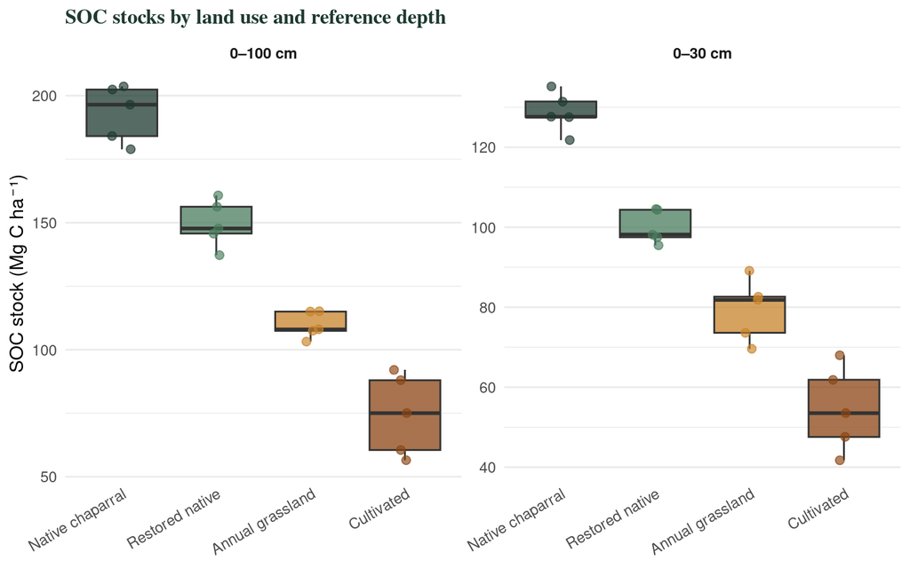

```r
soil_stocks_long <- soil_stocks %>%
  pivot_longer(c(stock_0_30, stock_0_100),
               names_to  = "depth_range",
               values_to = "stock") %>%
  mutate(depth_range = recode(depth_range,
    "stock_0_30"  = "0–30 cm",
    "stock_0_100" = "0–100 cm"
  ))

ggplot(soil_stocks_long,
       aes(x = land_use, y = stock, fill = land_use)) +
  geom_boxplot(alpha = 0.75, outlier.shape = 21,
               outlier.size = 2.5, outlier.fill = "white") +
  geom_jitter(width = 0.12, size = 2.2, alpha = 0.65,
              aes(color = land_use)) +
  scale_fill_manual(values  = lu_colors, guide = "none") +
  scale_color_manual(values = lu_colors, guide = "none") +
  scale_x_discrete(guide = guide_axis(angle = 30)) +
  facet_wrap(~ depth_range, scales = "free_y") +
  labs(
    title    = "SOC stocks by land use and reference depth",
    x        = NULL,
    y        = "SOC stock (Mg C ha\u207b\u00b9)"
  ) +
  theme_minimal(base_size = 12) +
  theme(
    plot.title   = element_text(family = "serif", face = "bold",
                                color = "#1e3a2f", size = 13),
    strip.text   = element_text(face = "bold"),
    panel.grid.major.x = element_blank()
  )
```

**📌 0–30 cm vs 0–100 cm stocks.** The 0–30 cm stock captures the biologically active topsoil where most carbon inputs and turnover occur. The 0–100 cm stock is the standard reference depth for national carbon inventories (IPCC 2006). The *ratio* of the two tells you how deeply carbon is stored: native vegetation has a lower ratio (more carbon at depth) while cultivated soils have a higher ratio (carbon concentrated near the surface by tillage).

## 6. Inferential Statistics: Do Land Uses Differ?

### 6.1 Check ANOVA assumptions

Before running ANOVA, verify that residuals are approximately normal and that group variances are similar.

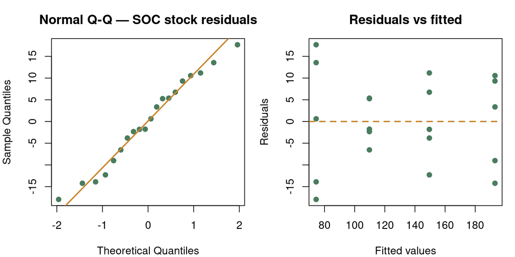

```r
# Focus on 0–100 cm stocks
lm_full <- lm(stock_0_100 ~ land_use, data = soil_stocks)

par(mfrow = c(1, 2), mar = c(4, 4, 3, 1))
qqnorm(residuals(lm_full), main = "Normal Q-Q — SOC stock residuals",
       col = "#4a7c5e", pch = 19)
qqline(residuals(lm_full), col = "#c8832a", lwd = 2)
plot(fitted(lm_full), residuals(lm_full),
     xlab = "Fitted values", ylab = "Residuals",
     main = "Residuals vs fitted",
     col = "#4a7c5e", pch = 19)
abline(h = 0, col = "#c8832a", lwd = 2, lty = 2)
```

```r
par(mfrow = c(1, 1))
```

```r
# Levene's test for homogeneity of variance
if (!requireNamespace("car", quietly = TRUE)) install.packages("car")
car::leveneTest(stock_0_100 ~ land_use, data = soil_stocks)
```

```
## Levene's Test for Homogeneity of Variance (center = median)
##       Df F value Pr(>F)
## group  3   1.876 0.1743
##       16
```

### 6.2 One-way ANOVA

```r
aov_result <- aov(stock_0_100 ~ land_use, data = soil_stocks)
summary(aov_result)
```

```
##             Df Sum Sq Mean Sq F value  Pr(>F)
## land_use     3  39261   13087   107.2 8.3e-11 ***
## Residuals   16   1953     122
## ---
## Signif. codes:  0 '***' 0.001 '**' 0.01 '*' 0.05 '.' 0.1 ' ' 1
```

### 6.3 Tukey HSD post-hoc test

A significant ANOVA F-test tells you that *at least one* pair of land uses differs. Tukey’s HSD identifies *which* pairs.

```r
tukey_result <- TukeyHSD(aov_result)
print(tukey_result)
```

```
##   Tukey multiple comparisons of means
##     95% family-wise confidence level
##
## Fit: aov(formula = stock_0_100 ~ land_use, data = soil_stocks)
##
## $land_use
##                                         diff        lwr       upr     p adj
## Restored native-Native chaparral   -43.55669  -63.54673 -23.56664 0.0000642
## Annual grassland-Native chaparral  -83.35077 -103.34081 -63.36072 0.0000000
## Cultivated-Native chaparral       -118.68967 -138.67972 -98.69963 0.0000000
## Annual grassland-Restored native   -39.79408  -59.78412 -19.80404 0.0001761
## Cultivated-Restored native         -75.13299  -95.12303 -55.14295 0.0000001
## Cultivated-Annual grassland        -35.33891  -55.32895 -15.34887 0.0006080
```

```r
# Tidy and select the columns we want for the table
tukey_tbl <- broom::tidy(tukey_result) %>%
  select(contrast, estimate, conf.low, conf.high, adj.p.value) %>%
  mutate(across(where(is.numeric), ~ round(.x, 3))) %>%
  arrange(adj.p.value)

tukey_tbl %>%
  kbl(
    caption   = "Tukey HSD pairwise comparisons — SOC stock 0–100 cm",
    col.names = c("Comparison", "Difference (Mg/ha)",
                  "Lower 95% CI", "Upper 95% CI", "Adj. p-value")
  ) %>%
  kable_styling(bootstrap_options = c("striped","hover"), full_width = FALSE) %>%
  row_spec(which(tukey_tbl$adj.p.value < 0.05),
           bold = TRUE, background = "#f1f8f1")
```

Tukey HSD pairwise comparisons — SOC stock 0–100 cm

| Comparison | Difference (Mg/ha) | Lower 95% CI | Upper 95% CI | Adj. p-value |
| --- | --- | --- | --- | --- |
| Restored native-Native chaparral | -43.557 | -63.547 | -23.567 | 0.000 |
| Annual grassland-Native chaparral | -83.351 | -103.341 | -63.361 | 0.000 |
| Cultivated-Native chaparral | -118.690 | -138.680 | -98.700 | 0.000 |
| Annual grassland-Restored native | -39.794 | -59.784 | -19.804 | 0.000 |
| Cultivated-Restored native | -75.133 | -95.123 | -55.143 | 0.000 |
| Cultivated-Annual grassland | -35.339 | -55.329 | -15.349 | 0.001 |

### 6.4 Non-parametric alternative: Kruskal-Wallis

```r
kruskal.test(stock_0_100 ~ land_use, data = soil_stocks)
```

```
##
##  Kruskal-Wallis rank sum test
##
## data:  stock_0_100 by land_use
## Kruskal-Wallis chi-squared = 17.857, df = 3, p-value = 0.0004707
```

### 6.5 Effect size: η² (eta-squared)

A significant p-value does not tell you how *large* the difference is. η² is the proportion of total variance explained by the treatment.

```r
ss_treatment <- sum(aov_result$effects[2:length(levels(soil_stocks$land_use))]^2)
ss_total     <- sum((soil_stocks$stock_0_100 - mean(soil_stocks$stock_0_100))^2)
eta_sq       <- ss_treatment / ss_total

cat(sprintf("eta-squared (\u03b7\u00b2) = %.3f\n", eta_sq))
```

```
## eta-squared (η²) = 0.953
```

```r
cat(sprintf(
  "Interpretation: %.0f%% of variance in SOC stock is explained by land use.\n",
  eta_sq * 100
))
```

```
## Interpretation: 95% of variance in SOC stock is explained by land use.
```

## 7. Summary

#### 💡 Key takeaways

- **Depth profiles always decrease with depth** — flip the y-axis with `scale_y_reverse()` so depth increases downward, matching the physical reality.
- **Exponential decay** (fit with `nls()`) is the standard SOC profile model. Parameter A gives surface SOC; k gives the decay rate. Larger k = steeper decline = less deep storage.
- **Carbon stocks require bulk density.** Concentration × bulk density × thickness × 0.1 converts g/kg to Mg C ha⁻¹. Always report the reference depth (e.g., 0–30 cm or 0–100 cm).
- **Native and restored vegetation consistently stores more carbon** than cultivated soils, particularly at depth where roots contribute to stable carbon pools.
- **Check ANOVA assumptions before testing.** Q-Q plots, residual plots, and Levene’s test are a minimal checklist. Log-transform stocks or use Kruskal-Wallis when assumptions are violated.
- **Report effect size alongside p-values.** η² tells you whether a statistically significant difference is also ecologically meaningful.

#### 💬 Discussion questions

1. The exponential decay model fits well for mineral soils but often underestimates SOC in the top 5 cm where organic matter accumulates. What modification to the model structure would you make, and how would you test whether it improves fit?
2. Bulk density was not measured in many historical soil surveys, so it is often estimated from pedotransfer functions using texture and organic matter content. How would uncertainty in bulk density propagate into the stock estimates?
3. Restored native sites were planted 10 years ago. The model predicts they will eventually approach native chaparral SOC levels. Using the fitted k values from both land uses, estimate how many years it would take for the restored site to reach 90% of the native chaparral surface SOC (A parameter).
4. The Tukey test adjusts p-values for multiple comparisons. If you were testing all six pairwise combinations of four land uses, what is the familywise error rate without correction at α = 0.05, and why does this motivate the adjustment?
5. Carbon sequestration projects often report “additional carbon” relative to a baseline land use. Using the mean stocks from this analysis, calculate the additional carbon stored by native chaparral relative to cultivated land at 0–100 cm depth. Express your answer in Mg C ha⁻¹ and in tonnes CO₂-equivalent per hectare.

## References

Batjes, N. H. 1996. Total carbon and nitrogen in the soils of the world. *European Journal of Soil Science* 47:151–163.

IPCC. 2006. *2006 IPCC Guidelines for National Greenhouse Gas Inventories*. Volume 4: Agriculture, Forestry and Other Land Use. IGES, Hayama, Japan.

Jobbágy, E. G., and R. B. Jackson. 2000. The vertical distribution of soil organic carbon and its relation to climate and vegetation. *Ecological Applications* 10:423–436.

Saxton, K. E., and W. J. Rawls. 2006. Soil water characteristic estimates by texture and organic matter for hydrologic solutions. *Soil Science Society of America Journal* 70:1569–1578.

EA030 RTricks | Prof. Marc Los Huertos | Pomona College | Activity 17 | Back to index